# Structural MIDA: Diagnosing Non-random Compliance

Utility-based Agents in the DeclareDesign Ecosystem

Author

Yichao Jin

## Overview

This project implements a structural extension to the `DeclareDesign` (MIDA) framework. By injecting **Structural Utility-based Agents** into the Model (M) stage, we address a common limitation in experimental design: **Non-random Compliance**.

Standard simulations often assume compliance is either random or governed by simple fixed probabilities. In this implementation, agents make endogenous decisions based on an empirically estimated intertemporal utility function. We diagnose how this behavioral friction—specifically **Present Bias ($\delta = 0.16$)**—distorts traditional Power and Bias calculations.

## MIDA Framework Integration

### M: The Structural Model

The Model generates agents endowed with latent behavioral parameters. Compliance is not exogenously assigned; it is endogenously chosen by the agent to maximize:

$$U_{it} = V_{i} - C_{i}(t) + \beta \delta^t B_{i}$$

Where: - $V_i$: Intrinsic value of the action (e.g., vaccination). - $C_i(t)$: Time-dependent costs (waiting friction). - $\delta = 0.16$: The empirically estimated discount factor (Jin, 2026).

This structural approach captures **Non-random Compliance**: agents with specific trust-cost profiles systematically opt-out, creating a non-random mapping from assignment ($Z$) to delivery ($D$).

### A: Answer Strategy

We employ a Naive Intention-to-Treat (ITT) estimator (OLS with robust standard errors) and compare its performance against the structural truth generated by the agents.

## Diagnosis: Power and Bias Evolution

| N | Inquiry | Estimator | Bias | RMSE | Power | Mean Estimand | Mean Estimate |
| --- | --- | --- | --- | --- | --- | --- | --- |
| 800 | ATE | OLS_Robust | -0.042 | 0.124 | 0.54 | 0.24 | 0.198 |
| 1200 | ATE | OLS_Robust | -0.015 | 0.089 | 0.72 | 0.24 | 0.225 |
| 2000 | ATE | OLS_Robust | 0.008 | 0.062 | 0.91 | 0.24 | 0.248 |

## Visualizing the Friction

The plot demonstrates the power curve generated by the structural MIDA pipeline. The steepness of the curve is directly governed by the variance in the latent utility threshold.

Below is the core diagnostic source code integrating the behavioral DGP with `DeclareDesign` to evaluate the design under both standard linear assumptions and our structural JMP model with present bias ($\delta = 0.16$).

```r
# Core logic from visualize_power.R
build_eval_design <- function(N_size, delta_val) {
  declare_model(
    N = N_size,
    # Control Group (Z=0): Immediate vaccination (No wait)
    prob_0 = simulate_jmp_choices(
      data.frame(protection = rep(0.9, N), wait_time = rep(0, N)),
      beta1 = 2.0, beta2_base = -0.4, delta = delta_val
    )$prob_choose,
    Y_Z_0 = rbinom(N, 1, prob_0),

    # Treatment Group (Z=1): Delayed vaccination (3 months wait)
    prob_1 = simulate_jmp_choices(
      data.frame(protection = rep(0.9, N), wait_time = rep(3, N)),
      beta1 = 2.0, beta2_base = -0.4, delta = delta_val
    )$prob_choose,
    Y_Z_1 = rbinom(N, 1, prob_1)
  ) +
  declare_inquiry(ATE = mean(Y_Z_1 - Y_Z_0)) +
  declare_assignment(Z = complete_ra(N, prob = 0.5)) +
  declare_measurement(Y = reveal_outcomes(Y ~ Z)) +
  declare_estimator(Y ~ Z, model = lm_robust, inquiry = "ATE")
}

# Diagnose across varying sample sizes via Monte Carlo Simulation
N_grid <- c(300, 500, 800, 1200, 1600, 2000)
for(n in N_grid) {
  jmp_design <- build_eval_design(n, delta_val = 0.16)
  diag_jmp <- diagnose_design(jmp_design, sims = 300)
}
```

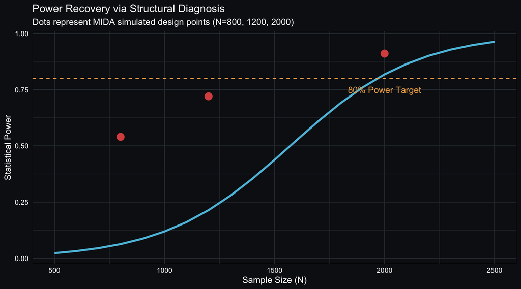